# Variable Selection (best subset and LASSO)

Shaobo Li

March, 2019

In this lab, we introduce different techniques of variable selection for linear regression. Note that these methods are not limited to linear regression, we will see them again in the following lectures and labs.

#### Get the data ready

```r
library(MASS)
data(Boston)
index <- sample(nrow(Boston),nrow(Boston)*0.90)
Boston.train <- Boston[index,]
Boston.test <- Boston[-index,]
```

## Classical Methods

Recall the different models we obtained from lab 3.

```r
model0<- lm(medv~lstat, data = Boston.train)
model1<- lm(medv~., data=Boston.train)
model2<- lm(medv~. -indus -age, data=Boston.train)
```

### Compare Model Fit (AIC and BIC)

```r
AIC(model0); BIC(model0)
AIC(model1); BIC(model1)
AIC(model2); BIC(model2)
```

[output not shown]

**Exercise**: Compare MSE, $R^2$, and MSPE of these three models.

### Best Subset Regression

The ‘leaps’ package provides procedures for best subset regression.

```r
install.packages('leaps')
```

```r
library(leaps)
```

Which subset of variables should you include in order to minimize BIC?

```r
#regsubsets only takes data frame as input
model.subset<- regsubsets(medv~.,data=Boston.train, nbest=2, nvmax = 13)
sum.subset<- summary(model.subset)
sum.subset
```

```
## Subset selection object
## Call: regsubsets.formula(medv ~ ., data = Boston.train, nbest = 2,
##     nvmax = 13)
## 13 Variables  (and intercept)
##         Forced in Forced out
## crim        FALSE      FALSE
## zn          FALSE      FALSE
## indus       FALSE      FALSE
## chas        FALSE      FALSE
## nox         FALSE      FALSE
## rm          FALSE      FALSE
## age         FALSE      FALSE
## dis         FALSE      FALSE
## rad         FALSE      FALSE
## tax         FALSE      FALSE
## ptratio     FALSE      FALSE
## black       FALSE      FALSE
## lstat       FALSE      FALSE
## 2 subsets of each size up to 13
## Selection Algorithm: exhaustive
##           crim zn  indus chas nox rm  age dis rad tax ptratio black lstat
## 1  ( 1 )  " "  " " " "   " "  " " " " " " " " " " " " " "     " "   "*"
## 1  ( 2 )  " "  " " " "   " "  " " "*" " " " " " " " " " "     " "   " "
## 2  ( 1 )  " "  " " " "   " "  " " "*" " " " " " " " " " "     " "   "*"
## 2  ( 2 )  " "  " " " "   " "  " " " " " " " " " " " " "*"     " "   "*"
## 3  ( 1 )  " "  " " " "   " "  " " "*" " " " " " " " " "*"     " "   "*"
## 3  ( 2 )  " "  " " " "   "*"  " " "*" " " " " " " " " " "     " "   "*"
## 4  ( 1 )  " "  " " " "   " "  " " "*" " " " " " " " " "*"     "*"   "*"
## 4  ( 2 )  " "  " " " "   "*"  " " "*" " " " " " " " " "*"     " "   "*"
## 5  ( 1 )  " "  " " " "   " "  "*" "*" " " "*" " " " " "*"     " "   "*"
## 5  ( 2 )  " "  " " " "   " "  " " "*" " " "*" " " " " "*"     "*"   "*"
## 6  ( 1 )  " "  " " " "   "*"  "*" "*" " " "*" " " " " "*"     " "   "*"
## 6  ( 2 )  " "  " " " "   " "  "*" "*" " " "*" " " " " "*"     "*"   "*"
## 7  ( 1 )  " "  " " " "   "*"  "*" "*" " " "*" " " " " "*"     "*"   "*"
## 7  ( 2 )  " "  "*" " "   " "  "*" "*" " " "*" " " " " "*"     "*"   "*"
## 8  ( 1 )  " "  "*" " "   "*"  "*" "*" " " "*" " " " " "*"     "*"   "*"
## 8  ( 2 )  " "  " " " "   "*"  "*" "*" " " "*" "*" " " "*"     "*"   "*"
## 9  ( 1 )  "*"  "*" " "   "*"  "*" "*" " " "*" " " " " "*"     "*"   "*"
## 9  ( 2 )  " "  "*" " "   "*"  "*" "*" " " "*" "*" " " "*"     "*"   "*"
## 10  ( 1 ) " "  "*" " "   "*"  "*" "*" " " "*" "*" "*" "*"     "*"   "*"
## 10  ( 2 ) "*"  "*" " "   " "  "*" "*" " " "*" "*" "*" "*"     "*"   "*"
## 11  ( 1 ) "*"  "*" " "   "*"  "*" "*" " " "*" "*" "*" "*"     "*"   "*"
## 11  ( 2 ) " "  "*" " "   "*"  "*" "*" "*" "*" "*" "*" "*"     "*"   "*"
## 12  ( 1 ) "*"  "*" " "   "*"  "*" "*" "*" "*" "*" "*" "*"     "*"   "*"
## 12  ( 2 ) "*"  "*" "*"   "*"  "*" "*" " " "*" "*" "*" "*"     "*"   "*"
## 13  ( 1 ) "*"  "*" "*"   "*"  "*" "*" "*" "*" "*" "*" "*"     "*"   "*"
```

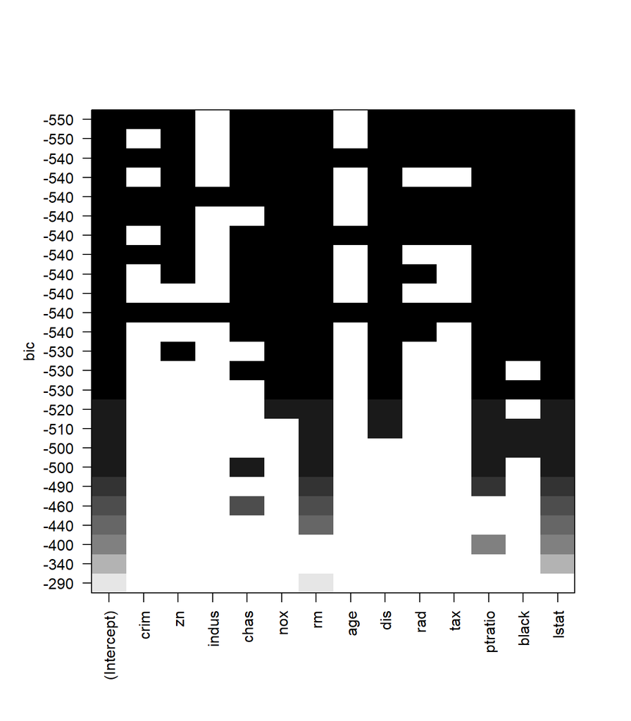

```r
plot(model.subset, scale="bic")
```

Each row represents a model. Black indicates that a variable is included in the model, while white indicates that it is not. The argument scale = “Cp”, “adjr2”, “r2” or “bic”.

We can get exactly the model we want.

```r
# extract certain criteria for all evaluated models
sum.subset$bic
```

```
##  [1] -343.1782 -291.8155 -443.4480 -396.0175 -486.4726 -458.2242 -498.8788
##  [8] -497.5202 -518.2231 -511.8368 -528.7868 -527.8837 -536.7975 -531.9842
## [15] -541.7792 -535.2909 -539.1098 -538.1807 -545.3451 -540.6837 -547.4719
## [22] -540.1292 -542.2629 -541.3595 -536.1563
```

```r
# which one is the best?
which.min(sum.subset$bic)
```

```
## [1] 21
```

```r
# get the model (selected variables)
coef(model.subset, id=which.min(sum.subset$bic))
```

```
##  (Intercept)         crim           zn         chas          nox
##  32.94061852  -0.09174867   0.05366862   3.04648364 -17.16088713
##           rm          dis          rad          tax      ptratio
##   3.90845873  -1.49137591   0.29443383  -0.01288694  -0.83534090
##        black        lstat
##   0.01015237  -0.48305400
```

** Exercise: ** Get the best model in terms of adjusted R square.

### Forward/Backward/Stepwise Regression Using AIC

To perform the Forward/Backward/Stepwise Regression in R, we need to define the starting points:

```r
nullmodel<- lm(medv~1, data=Boston.train)
fullmodel<- lm(medv~., data=Boston.train)
```

nullmodel is the model with no varaible in it, while fullmodel is the model with every variable in it.

#### Backward Elimination

```r
model.step.b<- step(fullmodel,direction='backward')
```

```
## Start:  AIC=1394.13
## medv ~ crim + zn + indus + chas + nox + rm + age + dis + rad +
##     tax + ptratio + black + lstat
##
##           Df Sum of Sq     RSS    AIC
## - indus    1      0.28  9161.9 1392.1
## - age      1     18.48  9180.1 1393.0
## <none>                  9161.6 1394.1
## - crim     1    167.99  9329.6 1400.4
## - tax      1    227.33  9389.0 1403.3
## - chas     1    269.53  9431.2 1405.3
## - black    1    297.36  9459.0 1406.7
## - zn       1    298.19  9459.8 1406.7
## - nox      1    345.59  9507.2 1409.0
## - rad      1    375.70  9537.3 1410.4
## - ptratio  1    787.06  9948.7 1429.6
## - dis      1   1178.78 10340.4 1447.2
## - lstat    1   1629.68 10791.3 1466.6
## - rm       1   1795.16 10956.8 1473.5
##
## Step:  AIC=1392.14
## medv ~ crim + zn + chas + nox + rm + age + dis + rad + tax +
##     ptratio + black + lstat
##
##           Df Sum of Sq     RSS    AIC
## - age      1     18.37  9180.3 1391.0
## <none>                  9161.9 1392.1
## - crim     1    167.72  9329.6 1398.4
## - chas     1    270.73  9432.6 1403.4
## - tax      1    280.09  9442.0 1403.8
## - black    1    297.89  9459.8 1404.7
## - zn       1    302.61  9464.5 1404.9
## - nox      1    376.42  9538.3 1408.5
## - rad      1    405.55  9567.5 1409.8
## - ptratio  1    801.60  9963.5 1428.3
## - dis      1   1227.36 10389.3 1447.3
## - lstat    1   1650.25 10812.2 1465.5
## - rm       1   1811.78 10973.7 1472.2
##
## Step:  AIC=1391.05
## medv ~ crim + zn + chas + nox + rm + dis + rad + tax + ptratio +
##     black + lstat
##
##           Df Sum of Sq     RSS    AIC
## <none>                  9180.3 1391.0
## - crim     1    167.91  9348.2 1397.3
## - chas     1    264.18  9444.5 1402.0
## - tax      1    285.00  9465.3 1403.0
## - black    1    288.94  9469.2 1403.2
## - zn       1    318.22  9498.5 1404.6
## - rad      1    423.60  9603.9 1409.6
## - nox      1    456.17  9636.5 1411.1
## - ptratio  1    828.95 10009.2 1428.4
## - dis      1   1259.24 10439.5 1447.5
## - rm       1   1815.13 10995.4 1471.2
## - lstat    1   2050.54 11230.8 1480.8
```

#### Forward Selection

```r
model.step.f<- step(nullmodel, scope=list(lower=nullmodel, upper=fullmodel), direction='forward')
```

#### Stepwise Selection (Output Omitted)

```r
model.step.s<- step(nullmodel, scope=list(lower=nullmodel, upper=fullmodel), direction='both')
```

#### Exercise

1. Comparing in-sample and out-of-sample performance between these reduced models.
2. Conduct 10-fold cross validation on the full sample and compare the CV scores.

**Note**: For pros and cons of variable/model selection using the common fit statistics: (adjusted) $R^2$, MSE, AIC, BIC, etc. refer to Ch9 in “Applied Linear Regression Models” by Kutner et al.

## Regularized Methods

### Least Absolute Shrinkage and Selection Operator (LASSO)

LASSO is probably one of the greatest revolution in statistics. It solves an important statistical question – dimension reduction. It facilates estimation and variable selection simultaneously. You may find more details from the author’s webpage http://statweb.stanford.edu/~tibs/lasso.html.

As a LASSO regression, we are minimizing following objective function

$$\frac{1}{n}\sum_{i=1}^{n}(Y_i-\boldsymbol{\beta}^TX_i)^2+\lambda\sum_{j=1}^{p}|\beta_j|,$$
where $\lambda$ is the shrinkage tuning parameter that controls the model sparsity.

#### Model Estimation

```r
install.packages("glmnet")
```

```r
library(glmnet)
```

A very detailed help document.

```r
?glmnet
```

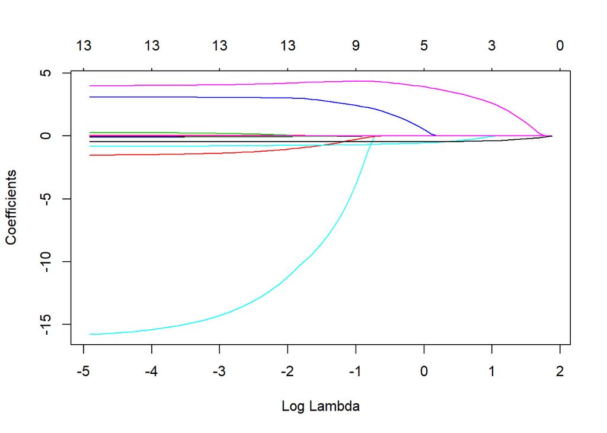

```r
library(dplyr)
X<- as.matrix(select(Boston.train, -medv))
Y<- as.matrix(select(Boston.train, medv))
lasso.fit<- glmnet(x=X, y=Y)
plot(lasso.fit, xvar = "lambda")
```

It is recommended to standardize the covariates when using regularized methods.

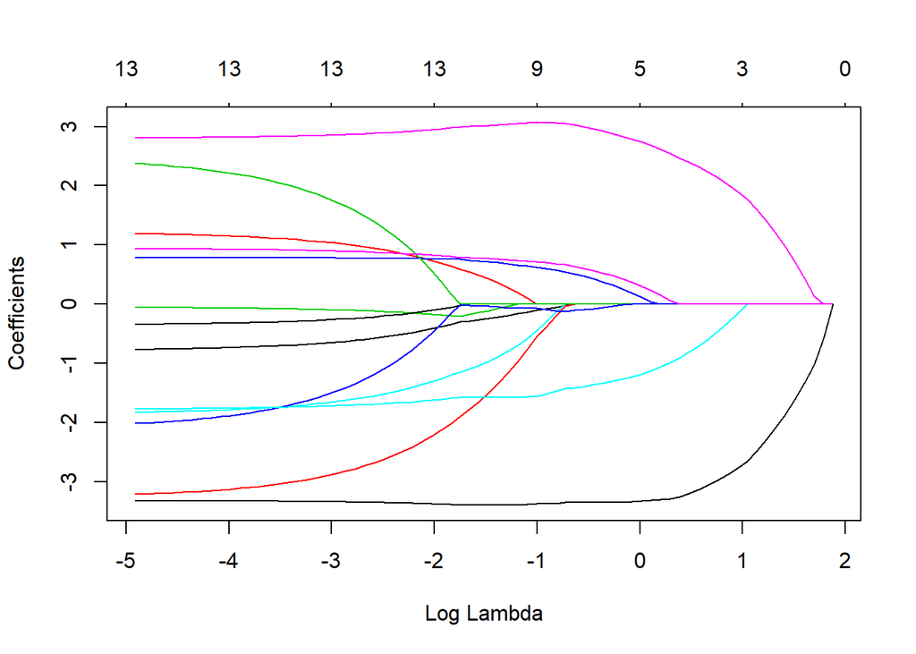

```r
Boston.X.std<- scale(select(Boston, -medv))
X.train<- as.matrix(Boston.X.std)[index,]
X.test<-  as.matrix(Boston.X.std)[-index,]
Y.train<- Boston[index, "medv"]
Y.test<- Boston[-index, "medv"]
lasso.fit<- glmnet(x=X.train, y=Y.train, family = "gaussian", alpha = 1)
plot(lasso.fit, xvar = "lambda")
```

By default, the `glmnet()` function estimates about 100 models with 100 different values of $\lambda$.

```r
lasso.fit$lambda
```

```
##  [1] 6.543323646 5.962032808 5.432382246 4.949784380 4.510059178
##  [6] 4.109397951 3.744330364 3.411694374 3.108608849 2.832448607
## [11] 2.580821680 2.351548595 2.142643499 1.952296956 1.778860275
## [16] 1.620831231 1.476841052 1.345642564 1.226099387 1.117176097
## [21] 1.017929252 0.927499222 0.845102748 0.770026149 0.701619148
## [26] 0.639289237 0.582496543 0.530749156 0.483598864 0.440637273
## [31] 0.401492273 0.365824806 0.333325938 0.303714181 0.276733050
## [36] 0.252148848 0.229748640 0.209338404 0.190741357 0.173796421
## [41] 0.158356826 0.144288842 0.131470619 0.119791131 0.109149217
## [46] 0.099452702 0.090617598 0.082567380 0.075232322 0.068548890
## [51] 0.062459195 0.056910492 0.051854721 0.047248091 0.043050700
## [56] 0.039226195 0.035741448 0.032566276 0.029673178 0.027037095
## [61] 0.024635194 0.022446671 0.020452571 0.018635621 0.016980083
## [66] 0.015471620 0.014097164 0.012844810 0.011703713 0.010663987
## [71] 0.009716628 0.008853430 0.008066915 0.007350273
```

We can get the estimated coefficients with different tuning parameter.

```r
coef(lasso.fit, s=0.1)
```

```
## 14 x 1 sparse Matrix of class "dgCMatrix"
##                      1
## (Intercept) 22.4525830
## crim        -0.5050712
## zn           0.8566307
## indus       -0.1429666
## chas         0.7705366
## nox         -1.4447460
## rm           2.9153997
## age         -0.1670622
## dis         -2.4844485
## rad          1.0294193
## tax         -0.8814104
## ptratio     -1.6628716
## black        0.8543590
## lstat       -3.3625199
```

```r
coef(lasso.fit, s=0.5)
```

```
## 14 x 1 sparse Matrix of class "dgCMatrix"
##                       1
## (Intercept) 22.43871414
## crim        -0.01521825
## zn           .
## indus        .
## chas         0.53425472
## nox          .
## rm           3.04347142
## age          .
## dis         -0.02078017
## rad          .
## tax         -0.12021143
## ptratio     -1.42347915
## black        0.65569303
## lstat       -3.35208146
```

```r
coef(lasso.fit, s=1)
```

```
## 14 x 1 sparse Matrix of class "dgCMatrix"
##                      1
## (Intercept) 22.4310537
## crim         .
## zn           .
## indus        .
## chas         0.1327848
## nox          .
## rm           2.7525957
## age          .
## dis          .
## rad          .
## tax          .
## ptratio     -1.1904205
## black        0.3165283
## lstat       -3.3315416
```

#### Choose the optimal tuning parameter

It is a natural question that which $\lambda$ should I use. Recall cross-validation, `glmnet` package provides cross-validation in order to select the optimal tuning parameter.

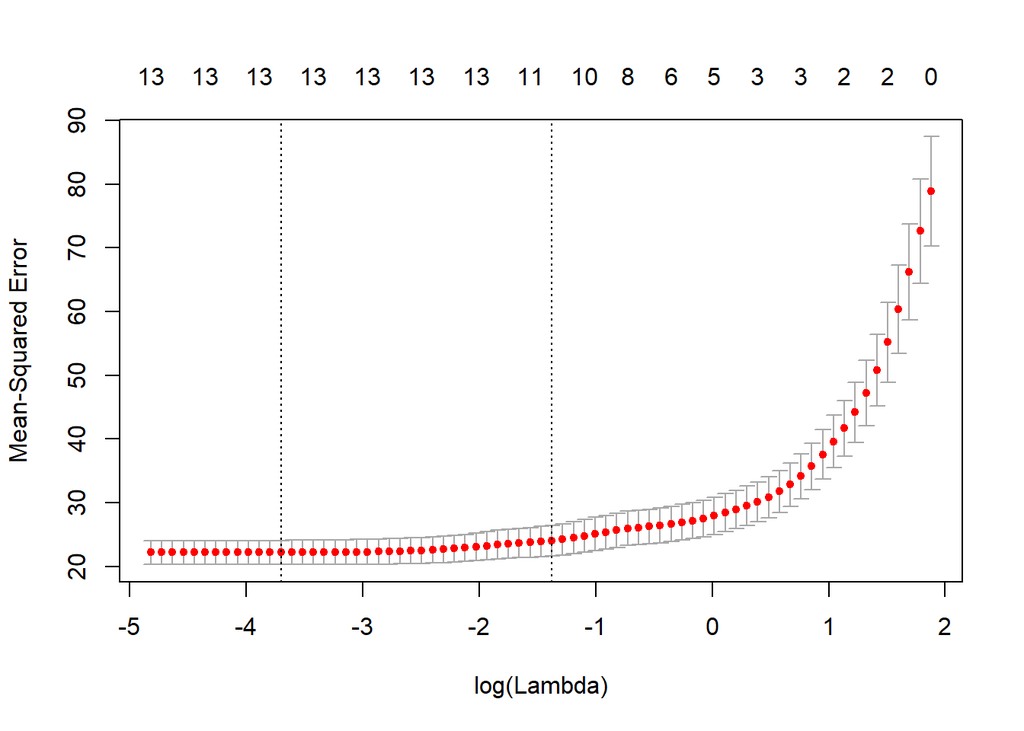

```r
cv.lasso<- cv.glmnet(x=X.train, y=Y.train, family = "gaussian", alpha = 1, nfolds = 10)
plot(cv.lasso)
```

The left bar is the $lambda$ that gives smallest cross-validation error (mean squared error). You can extract that lambda by using

```r
cv.lasso$lambda.min
```

```
## [1] 0.02463519
```

The right bar is the largest $lambda$ such that its cross-validation error (mean squared error) is within 1 standard error of the smallest cv error. You can extract that lambda by using

```r
cv.lasso$lambda.1se
```

```
## [1] 0.2521488
```

#### Prediction

Recall the `predict()` function. We can use it for LASSO object with slight change of the syntax.

```r
# prediction from 5 different models
pred.lasso1<- predict(lasso.fit, newx = X.test, s=0.1)
pred.lasso2<- predict(lasso.fit, newx = X.test, s=0.5)
pred.lasso3<- predict(lasso.fit, newx = X.test, s=1)
pred.lasso.min<- predict(lasso.fit, newx = X.test, s=cv.lasso$lambda.min)
pred.lasso.1se<- predict(lasso.fit, newx = X.test, s=cv.lasso$lambda.1se)
```

#### Exercise

Calculate the MSPE of these 5 models.

### High-dimensional regression

Ordinary least square method fails when the dimensionality is greater than sample size due to unidentifiability. However, with constraints, such as LASSO, there are feasible solutions for the optimization problem.

```r
genedata<- read.csv("http://homepages.uc.edu/~lis6/DataMining/Data/gene_exp.csv")
dim(genedata)
```

```
## [1]  60 501
```

Ordinary Least Square method does not work.

```r
lm.fit.high<- lm(Y~., data = genedata)
lm.fit.high
```

[output not shown]

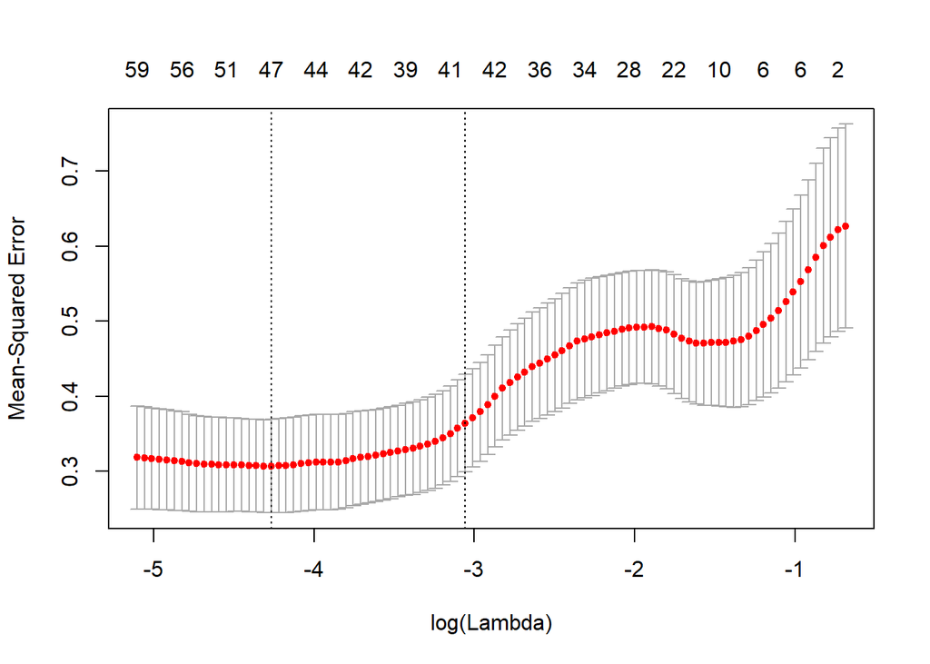

```r
lasso.fit.high<- glmnet(x= as.matrix(genedata[,-1]), y=genedata[,1], family = "gaussian", alpha=1)
cv.lasso.fit.high<- cv.glmnet(x= as.matrix(genedata[,-1]), y=genedata[,1], family = "gaussian", alpha=1)
plot(cv.lasso.fit.high)
```

```r
# obtain coefficient estimates
coef.high<- as.vector(coef(lasso.fit.high, s=cv.lasso.fit.high$lambda.1se))
coef.high[which(coef.high!=0)]
```

```
##  [1] -0.369333333  0.007398594  0.021323767  0.038455114  0.014424836
##  [6] -0.091535798 -0.102383416  0.138480026 -0.025849182 -0.073113300
## [11] -0.012187826  0.045804843  0.034710200 -0.034750136 -0.104414383
## [16] -0.068509459 -0.015684033 -0.013620461  0.006334025 -0.040253291
## [21] -0.004181583 -0.032284914  0.049525269 -0.029182337  0.005838446
## [26] -0.026824821 -0.020044670 -0.058231867  0.033752128  0.019784751
## [31] -0.040724546 -0.016105386 -0.031901813 -0.019214002  0.007147182
## [36] -0.032461202  0.070631840  0.011641831  0.015472043 -0.006445425
## [41] -0.011392363  0.054439165
```

```r
colnames(genedata[,-1])[which(coef.high!=0)]
```

```
##  [1] "X1451557_at"   "X1423439_at"   "X1417629_at"   "X1418706_at"
##  [5] "X1416125_at"   "X1418123_at"   "X1417709_at"   "X1423523_at"
##  [9] "X1416424_at"   "X1418616_at"   "X1416374_at"   "X1451488_at"
## [13] "X1415991_a_at" "X1421092_at"   "X1438654_x_at" "X1455106_a_at"
## [17] "X1420447_at"   "X1428620_at"   "X1437667_a_at" "X1453281_at"
## [21] "X1416156_at"   "X1424683_at"   "X1419213_at"   "X1423887_a_at"
## [25] "X1448562_at"   "X1419449_a_at" "X1449323_a_at" "X1451160_s_at"
## [29] "X1424352_at"   "X1436243_at"   "X1420966_at"   "X1430127_a_at"
## [33] "X1419510_at"   "X1416528_at"   "X1449248_at"   "X1422917_at"
## [37] "X1449565_at"   "X1448185_at"   "X1449009_at"   "X1435981_at"
## [41] "X1422821_s_at" "X1454706_at"
```

Back to top